# Visualization Lab 1: Introduction to ggplot2

Data Science Team

**Instructions**: With your lab partner(s) complete the tasks below. Don’t worry about understanding everything perfectly but do ask a member of the teaching team if something is preventing from moving forward. At the end of lab session, upload your own lab report as `HTML` on `Canvas`.

- If your file isn’t knitting for some reason, upload the `Rmd` instead.
- Labs will be graded on a credit / no credit basis so don’t worry about finishing. As long as you show *effort* you’ll get credit.
- You must upload your lab by 10:30am, so don’t forget to leave a moment at the end of lab!

# Step 0: A Little Data Wrangling

- [Download](http://web.stanford.edu/class/stats101/visualization/visualization.zip) and decompress the supplemental files for the visualization week into a subfolder of your Data Science 101 files.
- Create a new `RNotebook` in the visualization folder, add your name, and title the document something like “Data Viz Lab 1.” Also, delete everything below the header.
- In a new `R` code chunk, use `read.csv` to load the movies data set, which is found in the `data` folder. Notice that if you hit `tab` inside the quotes where you would type the file name `RStudio` will display the files in the `RNotebook`’s working directory.
- `ggplot2` expects data to be in a `data.frame`; confirm that `movies` is one by checking its `class`.

```r
class(movies)
```

[output not shown]

# Step 1: Loading Packages (a.k.a. Libraries)

Often, we wish to enhance `R` by loading additional packages. For example, the library `dplyr` offers a useful way to compactly display the contents of a `data.frame`. Libraries need to be loaded in each `RNotebook` to be used (but only need to be once per document). Add the following…

```r
library(dplyr)
glimpse(movies)
```

[output not shown]

# gg basics

- `ggplot` requires a `data.frame`.
- `aes` (as in ‘aesthestics’) is used to specify `x` and/or `y`
- Additional features are added (literally using `+`) to layer on additional function calls, including a wide variety of statistics .

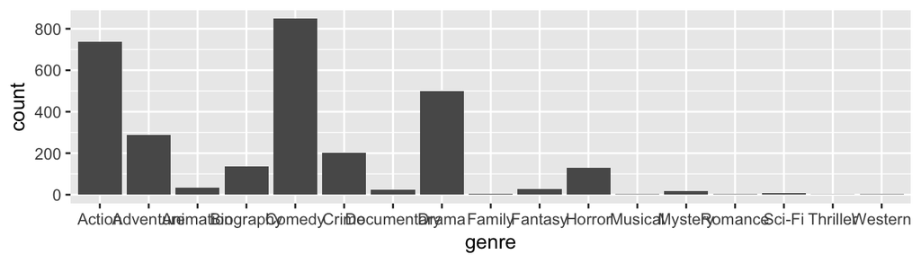

```r
library(ggplot2)
ggplot(movies, aes(x=genre)) + geom_bar()
```

# gg coding style

ggplots are often saved as objects to which additional features are added one or two at a time.

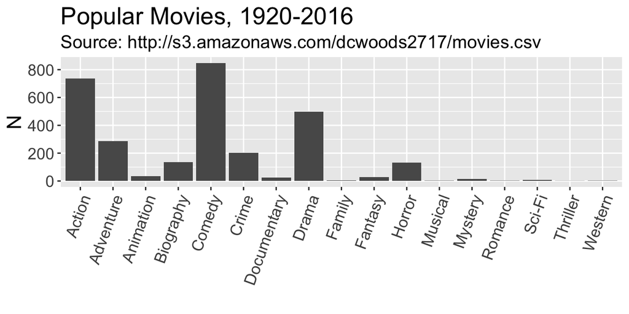

```r
g <- ggplot(movies, aes(x=genre)) + geom_bar()
g <- g + theme(text = element_text(size=16),
               axis.text.x = element_text(angle=70,hjust=1))
g <- g + labs(x="", y="N", title="Popular Movies, 1920-2016",
              subtitle="Source: http://s3.amazonaws.com/dcwoods2717/movies.csv")
g
```

# Tasks

1. Make a histogram with ggplot of any continuous variable found in `movies` using `geom_histogram()`.
2. Make a few different versions of the plot by altering `bins` or `binwidth` (parameters of `geom_histogram`) and/or by placing your `x` variable on a log scale (for example, `log(cast_facebook_likes - 1, base=10)`.
3. Pick the version of the graph you feel best represents the data and format the labels, titles, and so on such that the context is clear and everything is readable.
4. Now create a time series, i.e., using `geom_point()`, make `year` the `x` variable and choose another continuous variable to be `y`. Also, add a trend line with `geom_smooth()`. Your code will look something like:

```r
ggplot(movies, aes(x=year, y=profit)) + geom_point() + geom_smooth()
```

Format the graph and add a sentence explaining whether or not there appears to be a trend over time.

5. Choose a categorical variable to be `x` and a continuous variable to be `y`. Make two plots, one with `geom_boxpot()` and the other with `geom_violin()`. Which do you prefer and why?